# Assignment_3_AD654_Aishwarya_Malhotra

[figure not shown]

### Part I: Using Statistical Tests to Compare Marketing Campaigns

```python
import pandas as pd
import seaborn as sns
import matplotlib.pyplot as  plt
```

```python
df = pd.read_csv("lobster_land_campaigns_new.csv")
```

##### Solution - A

```python
# Looking at the dataframe
df.head()
```

|  | customerID | campaign_seen | total_spending |
| --- | --- | --- | --- |
| 0 | 1 | Relaxation and Leisure Drive | 59.102643 |
| 1 | 2 | Loyalty Reward Push | 93.802344 |
| 2 | 3 | Family Fun Campaign | 43.236077 |
| 3 | 4 | Relaxation and Leisure Drive | 78.009404 |
| 4 | 5 | Relaxation and Leisure Drive | 59.598420 |

> **💡Result💡-**

> By looking at the dataframe, we can say that campaign_seen and customerID are categorical data, where as total_spending is numerical data

##### Solution - B

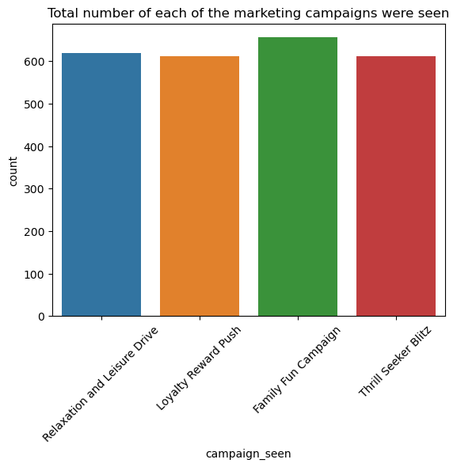

```python
#Countplot
sns.countplot(x='campaign_seen', data= df)
plt.xticks(rotation=45)
plt.title('Total number of each of the marketing campaigns were seen')
plt.show()
```

> **💡Interpretation of Result💡-**

> The bar graph illustrates the totak number of times each of the 4 marketing campaign were seen.

> No, It is not required that every group has to have the same sample size. The independent sample t-test can accomodate different sample sizes between the groups being compared. This flexibility allows for practical application in real-world scenarios where group sizes may naturally vary.

##### Solution - C

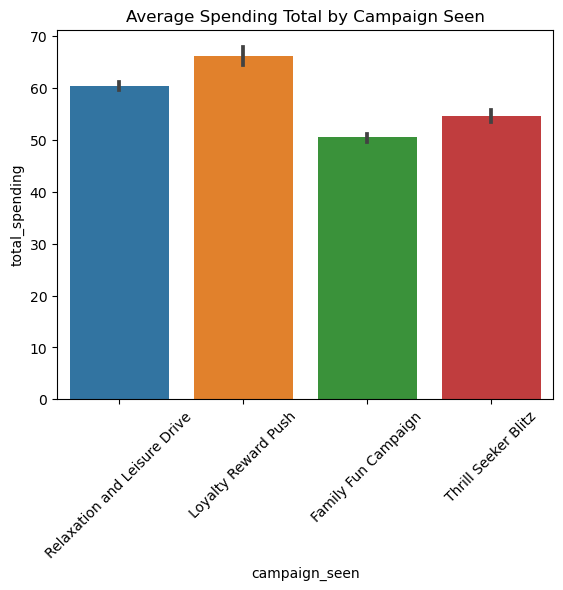

```python
# Bar plot
sns.barplot(x='campaign_seen', y='total_spending', data= df)
plt.xticks(rotation=45)
plt.title('Average Spending Total by Campaign Seen')
plt.show()
```

> **💡Interpretation of Result💡-**

> The graph illustrates the average spending total by marketing campaign seen. The campaign with the highest average total spending is "Loyalty Reward Push" at around `$65`. Loyalty programs often reward customers for spending more. This could encourage them to add more items to their cart or choose higher priced products to maximize their rewards.

##### Solution - D

> **💡Solutions💡-**

> a] The null hypothesis for each t-test will be that there is no difference in spending total between the two markeing campaign groups being compared.

> b] The alpha threshold, is the significance level used to determine whether to reject the null hypothesis. For this test, let's use apha = 0.05.

> c] ThBonferroni correction is a method used to adjust the significance level of statistical tests when multiple comparisons are made simultaneously. It aims to reduce the chance of making a Type I error (false positive) by lowering the significance level for each individual test.

> d] With the Bonferroni correction in mind, the new alpha threshol is calculated by dividing the desired overall alpha level by the number of tests being conducted. Since there are six tests (A vs B, A vs C, A vs D, B vs C, B vs D, C vs D), the new alpha threshold would be as calculated below:-

```python
#Bonferroni corrected alpha threshold
alpha_bonferroni = 0.05/6
alpha_bonferroni
```

```
0.008333333333333333
```

```python
from scipy.stats import ttest_ind
```

```python
groups = df["campaign_seen"].unique()
```

```python
#Perform t-test for each pair of groups with Bonferroni correction
for i in range(len(groups)):
    for j in range(i+1, len(groups)):
        group1 = df[df['campaign_seen'] == groups[i]]['total_spending']
        group2 = df[df['campaign_seen'] == groups[j]]['total_spending']

        # t-Test
        t_statistic, p_value = ttest_ind(group1, group2)

        # Print results with Bonferroni correction
        print(f"T-test between {groups[i]} and {groups[j]}:")
        print(f"T-statistic: {t_statistic}")
        print(f"P-value: {p_value}")
        if p_value < alpha_bonferroni:
            print("Null hypothesis rejected (significant)")
        else:
            print("Null hypothesis not rejected (not significant)")
        print()
```

```
T-test between Relaxation and Leisure Drive and Loyalty Reward Push:
T-statistic: -6.138880574028611
P-value: 1.1193589980082085e-09
Null hypothesis rejected (significant)

T-test between Relaxation and Leisure Drive and Family Fun Campaign:
T-statistic: 17.903776448987685
P-value: 4.0696926799038875e-64
Null hypothesis rejected (significant)

T-test between Relaxation and Leisure Drive and Thrill Seeker Blitz:
T-statistic: 8.170255322693286
P-value: 7.572443010176136e-16
Null hypothesis rejected (significant)

T-test between Loyalty Reward Push and Family Fun Campaign:
T-statistic: 17.24150901541523
P-value: 5.329847193156149e-60
Null hypothesis rejected (significant)

T-test between Loyalty Reward Push and Thrill Seeker Blitz:
T-statistic: 11.18977260645854
P-value: 9.68626552244726e-28
Null hypothesis rejected (significant)

T-test between Family Fun Campaign and Thrill Seeker Blitz:
T-statistic: -5.934590254062869
P-value: 3.797851847538929e-09
Null hypothesis rejected (significant)
```

> **💡Solution f]💡-**

> **Strongest difference -** Relaxation and Leisure Drive and Family Fun Campaign & Loyalty Reward Push and Family Fun Campaign.

> **Significant differnces -** Relaxation and Leisure Drive and Thrill Seeker Blitz, Loyalty Reward Push and Thrill Seeker Blitz & Family Fun Campaign and Thrill Seeker Blitz

> **Key Takeaway - Each marketing campaign attracts customers with distinct spending habits.**

> The t- test results reveal significant spending differences between all marketing campagign that each campaign attracts customers with varying spending habits. Lobster land can leverage this insight by analyzing customer demographics and preferences.

> **Actionable Recomendations**

> Identifying the campaign that resonates best with their target audience allows them to strategically allocate resources for the remaining off-season period, maximizing merchandise sales revenue.

##### Solution - E

> **💡Solution💡-**

> To move beyond a single campaign, Lobster Land's marketing team could explore a malti-variate analysis. This would allow them to examine how different customer characteristics (age, interest, etc) interact with various campaigns. This deeper understanding could inform the creation of targeted as placements or even the development of hybrid campaigns that combine elements from different approaches, maximizing reach and revenue across their diverse customer base.

### Part II: Chi-Square Goodness of Fit

##### Solution - A

> **💡Solution💡-**

> **Null Hypthesis (H0):** The distribution of visitor preferences for the various attraction at Lobbster Land aligns with management's expectations. The obseved frequencies (number of frequencies choosing each attraction) are consistent with the expected frequencies based on historical data (30% roller coasters, 25% water rides, 15% each for the others).

> **Alternative Hopothesis (H1):** The distribution of visitor preferences for the various attractions at Lobster Land does not align with the management's expectations. There is a statistically significant difference between the observed frequencies of visitor choices and the expected frequencies based on historical data.

> **Expected no of respondents**

> Total number of respondents - 500

> ● Roller Coasters: 0.30 * 500 = 150

> ● Water Rides: 0.25 * 500 = 125

> ● Lobsterama Restaurant: 0.15 * 500 = 75

> ● Marine Life Exhibit: 0.15 * 500 = 75

> ● Lobsterland Merchandise Shop: 0.15 * 500 = 75

##### Solution - B

```python
import scipy.stats as stats

# Observed frequencies
observed = [150, 120, 90, 80, 60]

# Expected frequencies
expected = [150, 125, 75, 75, 75]

# Chi- square test
chi2_stat, p_value = stats.chisquare(observed, f_exp=expected)

print(f"Chi-square statistics: {chi2_stat}")
print(f"P-value: {p_value}")
```

```
Chi-square statistics: 6.533333333333333
P-value: 0.16270219326739285
```

> **💡Interpretation of Results💡-**

> **Thus we fail to reject the null hypothesis.**

##### Solution - C

```python
observed = [150, 120, 90, 80, 60]

# Expected frequencies
expected = [150, 125, 75, 75, 75]

chi_square = 0

for obs, exp in zip(observed, expected):
    chi_square += ((obs - exp) ** 2)/ exp

print("Chi - square value", chi_square)
```

```
Chi - square value 6.533333333333333
```

> **💡Interpretation of Results💡-**

> Chi-square statistics is measure of difference between observed and expected frequencies (O-E).

> For each observed number in the table, subtract the corresponding expected number (O — E).

> Square the difference (O —E)².

> Divide the squares obtained for each cell in the table by the expected number for that cell (O – E)² / E.

> Sum all the values for (O – E)² / E. This is the chi-square statistic.

#### Solution - III: Wildcard:Word Cloud

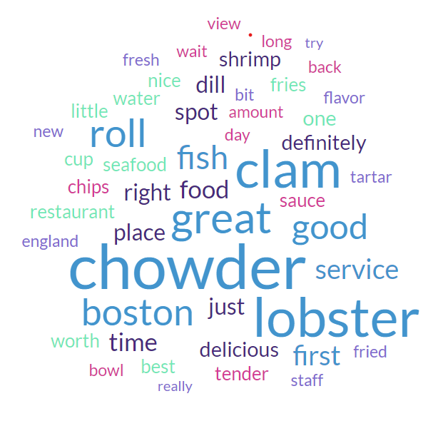

> **💡All my First Experiences💡-**

> **Boston Sail Loft - Yelp Reviews**

> The Boston Sail Loft word cloud transported me back to a **great** memory, a whrilwinf of firsts. The **fresh** and **seafood** reminded me of my first international trip, the nervous excitment of a **new** culture washing over me like ocean breeze. **Delicious** in the word cloud brought the reminder of pleasure of **first** bite of American fish and chips with a **cup** of hot coffee, though **flovor** tad **bit** bland for my taste... it was definetly not indian version of **fried** **fish** n **chips**! Maybe I would go next **time** and try out **Lobster** Being a Pisces **water** symbol reminds me of freedom. Unfamiliar ocean I crossed to get here to **Boston**. A symbol of leap of faith I took - a decision that could have gone wrong, but for once I choose myself - **definely** a memory **worth** celebrating again!